# Lecture 4: Introduction to bulk-RNAseq DE Analysis: Quality Checks

Megan Stumpf

09/30/2022

# 1. Objectives and Goals

The primary objective of this assignment is to illustrate that you understand the first steps of bulk-RNAseq data processing as it pertains to RNA sequence quality control. Additionally, this lecture will introduce some basic coding techniques aimed more efficiently analyze NGS datasets. By the end of this lecture and assignment you should be able to:

- run different software suites (`picardTools`) to check the quality of samples and alignment/mapping/quantification steps
- interpret quality control metrics as a way to address any problems with samples or analysis done previously
- define and identify the following terms: `for loop`
- implement `for loops`, `lists`, within R
- read in files and graph using `tidyverse`

# 2. Install/Load packages

This section is always required. You will load all packages necessary for the scope of the assignment in between the code blocks.

Write code to load in the following R packages:  
* tidverse  
* ggplot2  
* GGally

```r
# TO DO
library(tidyverse)
library(ggplot2)
library(GGally)
```

# 3. Alignment Quality Control

**Your Assigned Samples:**  
* 30_min_N4_peptide_PRN-694_rep1  
* 30_min_N4_peptide_PRN-694_rep2  
* 30_min_N4_peptide_PRN-694_rep3

## 3.1 Generating quality metrics

1. Write and execute your code here for generating metrics from Picard’s CollectRnaSeqMetrics.

```r
# OPTION 1 - in R
# TO DO
```

**OR**

```bash
# OPTION 2 - in bash
# TO DO

java -jar ~/shared-dir/software/picard/build/libs/picard.jar CollectRnaSeqMetrics I=alignment_sorted_1.bam O=~/bulkRNAseq/qc_metrics/alignment_sorted_1.txt REF_FLAT=~/shared-dir/data/bulk_RNA_seq/reference_data/mm10.refflat STRAND=NONE RIBOSOMAL_INTERVALS=~/shared-dir/data/bulk_RNA_seq/reference_data/mm10_primary_ribosomalRNA_interval_list.txt

java -jar ~/shared-dir/software/picard/build/libs/picard.jar CollectRnaSeqMetrics I=alignment_sorted_2.bam O=~/bulkRNAseq/qc_metrics/alignment_sorted_2.txt REF_FLAT=~/shared-dir/data/bulk_RNA_seq/reference_data/mm10.refflat STRAND=NONE RIBOSOMAL_INTERVALS=~/shared-dir/data/bulk_RNA_seq/reference_data/mm10_primary_ribosomalRNA_interval_list.txt

java -jar ~/shared-dir/software/picard/build/libs/picard.jar CollectRnaSeqMetrics I=alignment_sorted_3.bam O=~/bulkRNAseq/qc_metrics/alignment_sorted_3.txt REF_FLAT=~/shared-dir/data/bulk_RNA_seq/reference_data/mm10.refflat STRAND=NONE RIBOSOMAL_INTERVALS=~/shared-dir/data/bulk_RNA_seq/reference_data/mm10_primary_ribosomalRNA_interval_list.txt
```

2. Write and execute your code here for generating metrics from Picard’s CollectInsertSizeMetrics.

```r
# OPTION 1 - in R
# TO DO
```

**OR**

```bash
# OPTION 2 - in bash
# TO DO

java -jar ~/shared-dir/software/picard/build/libs/picard.jar CollectInsertSizeMetrics I=~/bulkRNAseq/bam_files/renamed/30_min_N4_peptide_PRN-694_rep1_sorted.bam O=~/bulkRNAseq/qc_metrics/renamed/InsertSizeMetrics/30_min_N4_peptide_PRN-694_rep1_sorted.txt H=~/bulkRNAseq/qc_metrics/renamed/InsertSizeMetrics/30_min_N4_peptide_PRN-694_rep1_sorted.pdf ASSUME_SORTED=true

java -jar ~/shared-dir/software/picard/build/libs/picard.jar CollectInsertSizeMetrics I=~/bulkRNAseq/bam_files/renamed/30_min_N4_peptide_PRN-694_rep2_sorted.bam O=~/bulkRNAseq/qc_metrics/renamed/InsertSizeMetrics/30_min_N4_peptide_PRN-694_rep2_sorted.txt H=~/bulkRNAseq/qc_metrics/renamed/InsertSizeMetrics/30_min_N4_peptide_PRN-694_rep2_sorted.pdf ASSUME_SORTED=true

java -jar ~/shared-dir/software/picard/build/libs/picard.jar CollectInsertSizeMetrics I=~/bulkRNAseq/bam_files/renamed/30_min_N4_peptide_PRN-694_rep3_sorted.bam O=~/bulkRNAseq/qc_metrics/renamed/InsertSizeMetrics/30_min_N4_peptide_PRN-694_rep3_sorted.txt H=~/bulkRNAseq/qc_metrics/renamed/InsertSizeMetrics/30_min_N4_peptide_PRN-694_rep3_sorted.pdf ASSUME_SORTED=true
```

3. Write and execute your code here for generating metrics from Picard’s MarkDuplicates.

```r
# OPTION 1 - in R
# TO DO
```

**OR**

```bash
# OPTION 2 - in bash
# TO DO

java -jar ~/shared-dir/software/picard/build/libs/picard.jar MarkDuplicates I=~/bulkRNAseq/bam_files/alignment_sorted_1.bam  O=~/bulkRNAseq/bam_files/renamed/30_min_N4_peptide_PRN-694_rep1_sorted.bam M=~/bulkRNAseq/qc_metrics/renamed/MarkDuplicates/30_min_N4_peptide_PRN-694_rep1_sorted.txt

java -jar ~/shared-dir/software/picard/build/libs/picard.jar MarkDuplicates I=~/bulkRNAseq/bam_files/alignment_sorted_2.bam O=~/bulkRNAseq/bam_files/renamed/30_min_N4_peptide_PRN-694_rep2_sorted.bam M=~/bulkRNAseq/qc_metrics/renamed/MarkDuplicates/30_min_N4_peptide_PRN-694_rep2_sorted.txt

java -jar ~/shared-dir/software/picard/build/libs/picard.jar MarkDuplicates I=~/bulkRNAseq/bam_files/alignment_sorted_3.bam O=~/bulkRNAseq/bam_files/renamed/30_min_N4_peptide_PRN-694_rep3_sorted.bam M=~/bulkRNAseq/qc_metrics/renamed/MarkDuplicates/30_min_N4_peptide_PRN-694_rep3_sorted.txt
```

## 3.2 Evaluating quality metrics

1. Populate all the empty fields in your csv file for your sample based upon the metrics above in Excel and save that file. Read in the metafile csv file.

```r
# TO DO

qcmetrics <- read_csv(file = "~/assignments/bulk_RNAseq_data_qc_metrics_for_students_updated.csv", )
qcmetrics <- na.omit(qcmetrics)
```

2. Using your favorite graphing tools in R (hint: ggplot for example), graph each of the following metrics from your csv file:

*Additionally, extra credit will be awarded if put in effort to make each of these graphs “pretty” using different point shapes, colors, adding titles and labels, etc… different from the R default settings in ggplot)*

1. grouped box plot by biological_group on the x-axis of the mean insert size on the y-axis
2. grouped box plot by biological_group on the x-axis of ribosomal contamination ratio on the y-axis
3. pick one type of correlation plot and plot the correlation of biological_groups along with your choice of any of the 4 following metrics: PCT_RIBOSOMAL_BASES, PCT_CODING_BASES, PCT_UTR_BASES, PCT_INTRONIC_BASES, PCT_INTERGENIC_BASES, MEDIAN_3PRIME_BIAS, MEDIAN_INSERT_SIZE, PERCENT_DUPLICATION (hint: use the GGally library)
4. scatter plot of percent of uniquely mapped reads on the x-axis and percent of multi-mapped reads on the y-axis, where each point is a sample and each sample is colored by its replicate number
5. grouped box plots of replicate groups on the x-axis and total reads on the y-axis. Additionally, plot each sample on each boxplot as a dot. (Hint: Google how to add a `geom_jitter()` plot to your ggplot boxplots)
6. generate a the same plot in e) except instead of boxplots, turn them into violin plots.

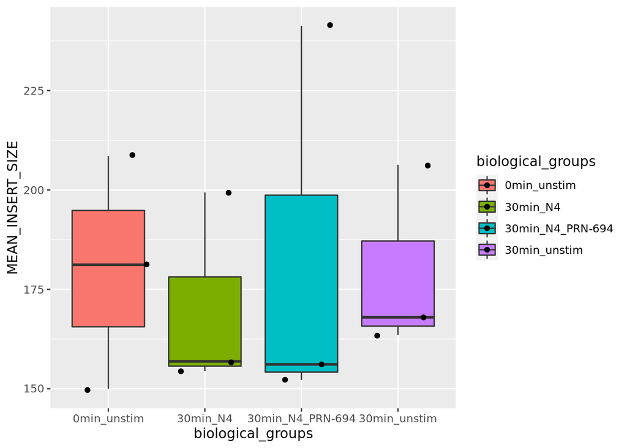

```r
#TO DO

#MEAN_INSERT_SIZE
plot_a <- ggplot(qcmetrics, aes(biological_groups, MEAN_INSERT_SIZE, fill=biological_groups)) +
            geom_boxplot() +
            geom_jitter()
plot_a
```

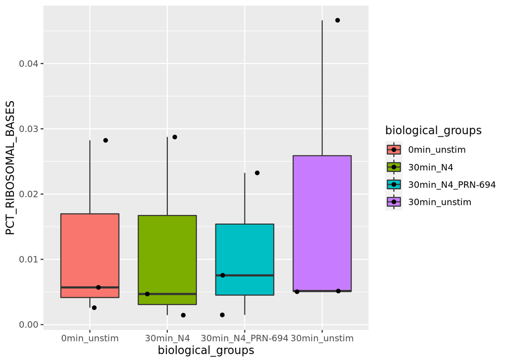

```r
#PCT_RIBOSOMAL_BASES
plot_b <- ggplot(qcmetrics, aes(biological_groups, PCT_RIBOSOMAL_BASES, fill=biological_groups)) +
            geom_boxplot() +
            geom_jitter()
plot_b
```

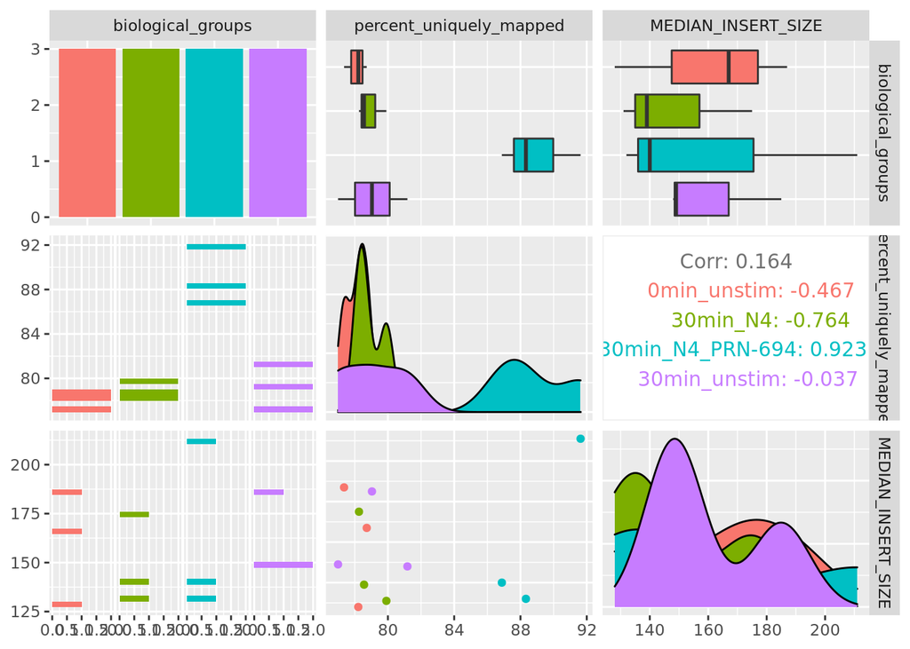

```r
#Correlation Plots
plot_c <- ggpairs(qcmetrics, columns = c(2,5,27), aes(colour=biological_groups))
plot_c
```

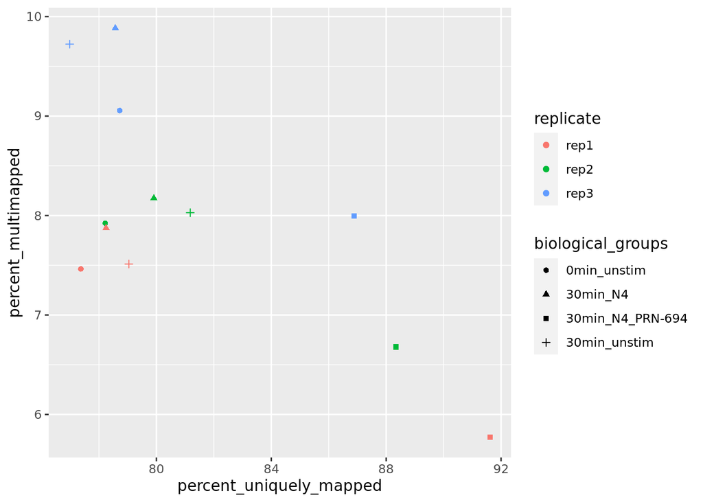

```r
#Scatter Plot
plot_d <- ggplot(qcmetrics, aes(percent_uniquely_mapped, percent_multimapped, color=replicate, shape=biological_groups)) +
            geom_jitter()
plot_d
```

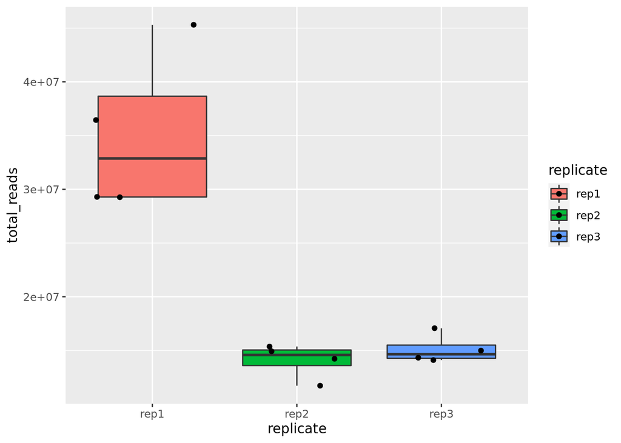

```r
#Box Plots
plot_e <- ggplot(qcmetrics, aes(replicate, total_reads, fill=replicate)) +
            geom_boxplot() +
            geom_jitter()
plot_e
```

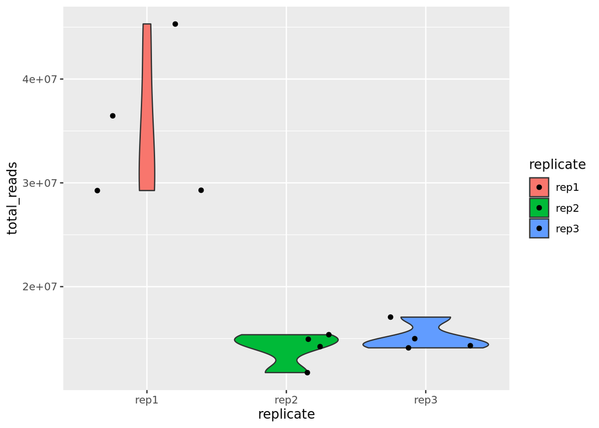

```r
#Violin Plots
plot_f <- ggplot(qcmetrics, aes(replicate, total_reads, fill=replicate)) +
            geom_violin() +
            geom_jitter()
plot_f
```

3. Write a for loop to loop through your metadata frame by row and use 4 `print()` statements to print out the short_sample_ID, biological_groups, total_reads, and PCT_RIBOSOMAL_BASES columns for each sample.

```r
# TO DO

for (tempVariable in 1:nrow(qcmetrics)) {
  print(qcmetrics[tempVariable,"short_sample_ID"])
  print(qcmetrics[tempVariable,"biological_groups"])
  print(qcmetrics[tempVariable,"total_reads"])
  print(qcmetrics[tempVariable,"PCT_RIBOSOMAL_BASES"])
}
```

```
## # A tibble: 1 × 1
##   short_sample_ID
##   <chr>
## 1 0_min_unstimulated_rep1
## # A tibble: 1 × 1
##   biological_groups
##   <chr>
## 1 0min_unstim
## # A tibble: 1 × 1
##   total_reads
##         <dbl>
## 1    29292101
## # A tibble: 1 × 1
##   PCT_RIBOSOMAL_BASES
##                 <dbl>
## 1             0.00260
## # A tibble: 1 × 1
##   short_sample_ID
##   <chr>
## 1 0_min_unstimulated_rep2
## # A tibble: 1 × 1
##   biological_groups
##   <chr>
## 1 0min_unstim
## # A tibble: 1 × 1
##   total_reads
##         <dbl>
## 1    11721059
## # A tibble: 1 × 1
##   PCT_RIBOSOMAL_BASES
##                 <dbl>
## 1             0.00571
## # A tibble: 1 × 1
##   short_sample_ID
##   <chr>
## 1 0_min_unstimulated_rep3
## # A tibble: 1 × 1
##   biological_groups
##   <chr>
## 1 0min_unstim
```

[output cut: 137 more lines]

```
##   short_sample_ID
##   <chr>
## 1 30_min_N4_peptide_rep3
## # A tibble: 1 × 1
##   biological_groups
##   <chr>
## 1 30min_N4
## # A tibble: 1 × 1
##   total_reads
##         <dbl>
## 1    14326037
## # A tibble: 1 × 1
##   PCT_RIBOSOMAL_BASES
##                 <dbl>
## 1              0.0288
```

## **Critical Thinking Exercises**

### Question 1

Compare and contrast your findings on the qc graphs you generated above between different biological groups. Are there any large outliers in your samples? Which metrics correlate with each other? Which metrics are anti-correlated? Provide one explanation why the correlation/anti-correlation makes sense for the your choice of corrleation metric.

### Question 2

What may be a possible reason (there may be many but just list one) when a high ribosomal contamination percentage is seen in a project or data set?

A high ribosomal contamination percentage is seen in a project or data set may be due to an insufficiently ribosomal depletion library prep prior to sequencing.

### Question 3

List a possible reason (there are many but just list one) why a low alignment percentage may be seen? List a possible reason (there are many but just list one) why a high multi-mapping rate may be seen? What might you do to try to address either issue in your analysis?

A low alignment percentage may be seen if the sequencing run was contaminated and reads are not aligning to the reference genome you think composes the majority of the reads in the run. A high multi-mapping rate may be seen if the reads are too short, or trimming removed too many bases to make the read short, that causes the short span to be found in multiple regions of the reference genome. To address either issue in my analyses, I would check both the read length of the multimapped reads as well as blast overrepresented sequences found in my unmapped reads.

### Question 4

I want to create a list of numbers, therefore, I run the following code in R: `myList <- c(0, 5, -2)`. I write a for loop as follows:

```r
for (i in myList) {
  squareValue <- i*i
  print(paste("The square of ", i, " is:", squareValue, sep = ""))
}
```

How many times will `i` loop through the for loop? What will get printed at each interaction? What is the value of `i` the 2nd time it enters the loop? What is the value of the variable `squareValue` the 3rd time it enters the loop?

i will look through through the for loop three times, once for each of the values in the list. At each interaction, the square value of the number in that list position will be printed. The 2nd time it enters the loop, it submits an i value of 5, for a square of 25. the squareValue for the third list item is 4.

### Question 5

Personally, I hate bar plots for most biological data representation, especially if they are trying to show statistical significance between bar groups. Typically, I think box plots and violin plot should be used most of the time for biological data representation. What advantage does a box plot or violin plot have over a typical bar plot? Additionally, what is the difference between a boxplot and a violin plot? What can a boxplot tell you that a violin plot can’t, and what can a violin plot tell you that a box plot doesn’t?

A box plot or violin plot show the distribution of the data points that compose the spread of the data, not just the bars plotted with the average for the bar height and a standard error bar. Additionally, the difference between a boxplot and a violin plot is that a violin plot scales the thickness of the plot to the number of data points in that region, whereas the boxplot only shows the spread. A boxplot, however, can you show you the quartiles of your data more effeciently than a violin plot. A violin plot, as described above, shows the density of the points making up the plot at each region of the plot.

# 4. Session info

Finally, we will **always** end our Rmarkdown documents with the session information. This provides version control so if there is any issue with your code or results, we can trace it back to the session information and try running it on the same system. You just need to always include this section, although no changes will ever need to be made here.

[session information not shown]